# Analytics 201: Homework 1

Lucy Wu

10/12/2020

This is a (optional) set of questions meant to provide a quick self-assessment of your understanding of Analytics 201 so far.

If you have any questions, please post on the Analytics 201 Piazza or attend office hours!

## Questions

These questions will use a sample of the arrests dataset. You may also find it helpful to use libraries like `lubridate` and `dplyr`.

0. Read in the `arrestssample.csv` and `officers.csv` datasets.
1. Which year in the dataset has the most arrests?
2. How many arrests in 2010 were logged under driving-related statutes (i.e., the statute description contains the word “driving”)?
3. What is the most common statute cited in an arrest at night (11PM - 5AM)? In the afternoon (12PM - 5PM)?
4. What is the average number of arrests in 2010 for officers appointed more than 10 years ago (i.e., before 2000) vs. officers appointed less than 10 years ago? (Hint: You’ll need to use `join()` for this.)
5. Plot a histogram of arrests per officer in 2010.

## Solutions

```r
# Some helpful libraries
library(lubridate)
library(magrittr)
library(dplyr)
library(tidyr)
```

**0.** Read in the `arrestssample.csv` and `officers.csv` datasets.

```r
arrests <- read.csv('../arrestssample.csv')
officers <- read.csv('../officers.csv')
```

**1.** Which year in the dataset has the most arrests?

```r
arrests %>%
  mutate(year = year(mdy(date))) %>%
  group_by(year) %>%
  summarize(num_arrests = n()) %>%
  top_n(1, num_arrests)
```

```
## # A tibble: 1 x 2
##    year num_arrests
##   <dbl>       <int>
## 1  2006        1103
```

**2.** How many arrests in 2010 were logged under driving-related statutes (i.e., the statute description contains the word “driving”)?

There appear to be 19 driving-related arrests in 2010:

```r
# Filter to only 2010 arrests
arrests_2010 <- arrests %>%
  mutate(year = year(mdy(date))) %>%
  filter(year == 2010)

# Count all driving-related arrests using grep()
length(grep('driving', tolower(arrests_2010$statute_description)))
```

```
## [1] 19
```

**3.** What is the most common statute cited in an arrest at night (11PM - 5AM)? In the afternoon (12PM - 5PM)?

Note that 11PM = hour 23, 5AM = hour 5, 12PM = hour 12, 5PM = hour 17.

In both the night and the afternoon, the most common statute description was “issuance of warrant.”

```r
# For the night
arrests %>%
  filter((hour >= 23) | (hour < 5)) %>%
  group_by(statute_description) %>%
  summarize(num_arrests = n()) %>%
  top_n(1, num_arrests)
```

```
## # A tibble: 1 x 2
##   statute_description num_arrests
##   <chr>                     <int>
## 1 ISSUANCE OF WARRANT         217
```

```r
# For the afternoon
arrests %>%
  filter((hour >= 12) & (hour < 17)) %>%
  group_by(statute_description) %>%
  summarize(num_arrests = n()) %>%
  top_n(1, num_arrests)
```

```
## # A tibble: 1 x 2
##   statute_description num_arrests
##   <chr>                     <int>
## 1 ISSUANCE OF WARRANT         249
```

**4.** What is the average number of arrests in 2010 for officers appointed more than 10 years ago (i.e., before 2000) vs. officers appointed less than 10 years ago? (Hint: You’ll need to use `join()` for this.)

```r
# Compute number of arrests per officer in 2010
arrests_per_officer_2010 <- arrests %>%
  mutate(arrest_year = year(mdy(date))) %>%
  filter(arrest_year == 2010) %>%
  group_by(off_id) %>%
  summarize(num_arrests = n())

# Filter only to officers appointed before 2010
officers_2010 <- officers %>%
  mutate(appointed_year = year(mdy(off_appointed_date))) %>%
  filter(appointed_year < 2010)

# Join with officers data
# Need to use a right join here to ensure that officers who made no arrests are included
arrests_with_officer_2010 <- right_join(arrests_per_officer_2010, officers_2010, by='off_id')
arrests_with_officer_2010$num_arrests <- arrests_with_officer_2010$num_arrests %>% replace_na(0)

arrests_with_officer_2010 %>%
  mutate(year_bool = ifelse(appointed_year < 2000, '>10 years ago', '<10 years ago')) %>%
  group_by(year_bool) %>%
  summarize(avg_arrests = mean(num_arrests))
```

```
## # A tibble: 2 x 2
##   year_bool     avg_arrests
##   <chr>               <dbl>
## 1 <10 years ago      0.113
## 2 >10 years ago      0.0175
```

**5.** Plot a histogram of arrests per officer in 2010.

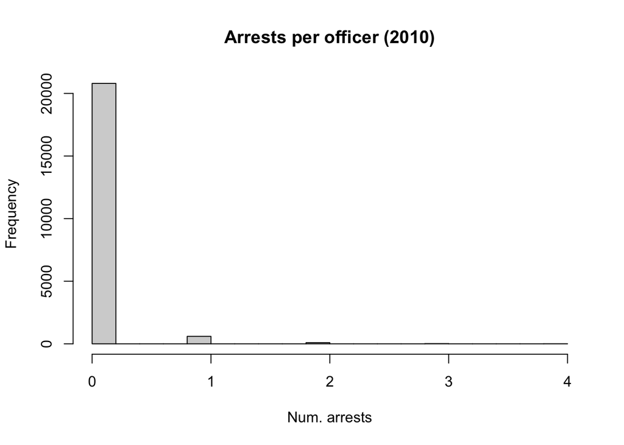

```r
hist(arrests_with_officer_2010$num_arrests, main='Arrests per officer (2010)', xlab='Num. arrests')
```